First, let us download the data by uncommenting the two lines below. If data is not available at that link, download from [here](https://www.kaggle.com/c/digit-recognizer/data).

```r
dataDirectory <- "C:/RProject/data"
if (!file.exists(paste(dataDirectory,'/train.csv',sep="")))
{
  link <- 'https://apache-mxnet.s3-accelerate.dualstack.amazonaws.com/R/data/mnist_csv.zip'
  if (!file.exists(paste(dataDirectory,'/mnist_csv.zip',sep="")))
    download.file(link, destfile = paste(dataDirectory,'/mnist_csv.zip',sep=""))
  unzip(paste(dataDirectory,'/mnist_csv.zip',sep=""), exdir = dataDirectory)
  if (file.exists(paste(dataDirectory,'/test.csv',sep="")))
    file.remove(paste(dataDirectory,'/test.csv',sep=""))
}
```

Now we can read data into R and get an idea of how it looks.

```r
train <- read.csv(paste(dataDirectory,'/train.csv',sep=""), header=TRUE, nrows=20)
```

We have 20 rows and 785 columns, we will look at the first 6 columns and the last 6 columns:

```r
tail(train[,1:6])
```

```
##    label pixel0 pixel1 pixel2 pixel3 pixel4
## 15     3      0      0      0      0      0
## 16     1      0      0      0      0      0
## 17     2      0      0      0      0      0
## 18     0      0      0      0      0      0
## 19     7      0      0      0      0      0
## 20     5      0      0      0      0      0
```

```r
tail(train[,(ncol(train)-5):ncol(train)])
```

```
##    pixel778 pixel779 pixel780 pixel781 pixel782 pixel783
## 15        0        0        0        0        0        0
## 16        0        0        0        0        0        0
## 17        0        0        0        0        0        0
## 18        0        0        0        0        0        0
## 19        0        0        0        0        0        0
## 20        0        0        0        0        0        0
```

We have 785 columns, the first column is the data label and then we have 784 columns named pixel0,…,pixel783 with the pixel values. Our images are 28x28 = 784, so everything looks ok.

Before we start building models, it is always a good idea to ensure your data is in the correct format and that your features and labels are aligned correctly. Lets plot the first 9 instances with their data labels. To do this, we create a helper function called plotInstance that takes in the pixel values and outputs the image with an optional header.

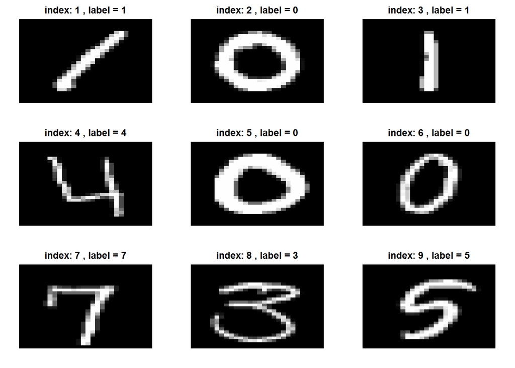

```r
plotInstance <-function (row,title="")
{
  mat <- matrix(row,nrow=28,byrow=TRUE)
  mat <- t(apply(mat, 2, rev))
  image(mat, main = title,axes = FALSE, col = grey(seq(0, 1, length = 256)))
}
par(mfrow = c(3, 3))
par(mar=c(2,2,2,2))
for (i in 1:9)
{
  row <- as.numeric(train[i,2:ncol(train)])
  plotInstance(row, paste("index:",i,", label =",train[i,1]))
}
```

We can try some image manipulation. Here we will ‘move’ the images up 6 pixels. We will use this later in our model evaluation.

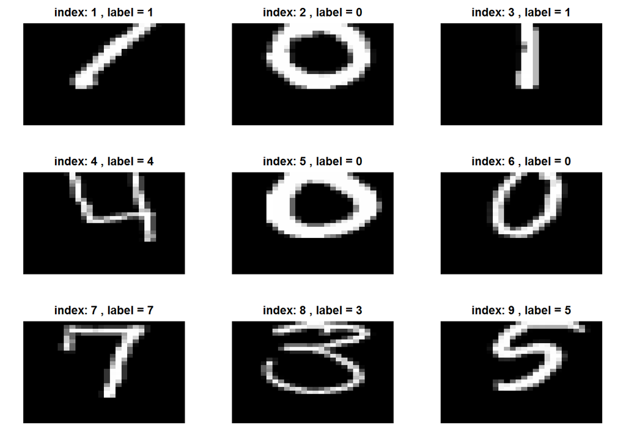

```r
par(mfrow = c(3, 3))
par(mar=c(2,2,2,2))
skiprows<-6
test2<-train
test2[]<-0
test2[,1:(ncol(test2)-28*skiprows)]<-train[,(28*skiprows):(-1+ncol(train))]
for (i in 1:9)
{
  row <- as.numeric(test2[i,2:ncol(test2)])
  plotInstance(row, paste("index:",i,", label =",train[i,1]))
}
```